# Notebook 08 – Solutions

## Getting Started

Before running this notebook, select “Session > Restart R and Clear Output” in the menu above to start a new R session. You may also have to hit the broom in the upper right-hand corner of the window. This will clear any old data sets and give us a blank slate to start with.

After starting a new session, run the following code chunk to load the libraries and data that we will be working with today.

I have set the options `message=FALSE` and `echo=FALSE` to avoid cluttering your solutions with all the output from this code.

## Reading the Data

Today we are going to look at a subset of a well-known text analysis corpus call NewsGroups-20. It’s an old set of mailing list archives from 20 different categories.

```r
docs <- read_csv("../data/newsgroups.csv.bz2")
anno <- read_csv("../data/newsgroups_token.csv.bz2")
```

## Questions

### Supervised Learning

Build an elastic net model to determine the category of the newsgroup messages:

```r
# Question 01
model <- dsst_enet_build(anno, docs)
```

```
## as(<dgCMatrix>, "dgTMatrix") is deprecated since Matrix 1.5-0; do as(., "TsparseMatrix") instead
```

Produce a confusion matrix for the messages using just the validation data. Take note of any commonly confused categories:

```r
# Question 02
model$docs %>%
  filter(train_id == "valid") %>%
  select(label, pred_label) %>%
  table()
```

```
##                           pred_label
## label                      alt.atheism comp.graphics
##   alt.atheism                       15             0
##   comp.graphics                      0             7
##   comp.os.ms-windows.misc            0             0
##   comp.sys.ibm.pc.hardware           0             2
##   comp.sys.mac.hardware              2             5
##   comp.windows.x                     0             1
##   misc.forsale                       0             2
##   rec.autos                          0             0
##   rec.motorcycles                    0             0
##   rec.sport.baseball                 1             0
##   rec.sport.hockey                   0             0
##   sci.crypt                          0             1
##   sci.electronics                    0             1
##   sci.med                            2             1
##   sci.space                          0             0
##   soc.religion.christian             1             0
##   talk.politics.guns                 1             0
##   talk.politics.mideast              1             0
##   talk.politics.misc                 0             1
##   talk.religion.misc                 7             1
##                           pred_label
## label                      comp.os.ms-windows.misc comp.sys.ibm.pc.hardware
##   alt.atheism                                    0                        0
##   comp.graphics                                  6                        0
##   comp.os.ms-windows.misc                       18                        1
##   comp.sys.ibm.pc.hardware                       5                       12
##   comp.sys.mac.hardware                          0                        2
##   comp.windows.x                                 4                        1
##   misc.forsale                                   2                        2
##   rec.autos                                      0                        0
##   rec.motorcycles                                0                        0
##   rec.sport.baseball                             0                        0
##   rec.sport.hockey                               0                        0
##   sci.crypt                                      0                        2
##   sci.electronics                                1                        2
##   sci.med                                        1                        0
##   sci.space                                      1                        0
##   soc.religion.christian                         0                        0
```

[output cut: 143 more lines]

```
##   comp.windows.x                           15
##   misc.forsale                             12
##   rec.autos                                14
##   rec.motorcycles                          10
##   rec.sport.baseball                       19
##   rec.sport.hockey                         16
##   sci.crypt                                13
##   sci.electronics                          22
##   sci.med                                  19
##   sci.space                                16
##   soc.religion.christian                   11
##   talk.politics.guns                       22
##   talk.politics.mideast                    16
##   talk.politics.misc                       21
##   talk.religion.misc                       25
```

Look at the coefficients from the model; perhaps use `lambda_num = 30`. Use the code from Project 2 to look at the positive (and negative, if there are any) terms associated with each category. Do the terms seem to correspond to the categories in an expected way? Note: You can pipe the whole thing into the function `View()` if you want a better way to look at the output in RStudio.

```r
# Question 03
dsst_coef(model$model, lambda_num = 30, to_tibble = TRUE) %>%
  filter(term != "(Intercept)") %>%
  pivot_longer(names_to = "label", values_to = "coef", cols = -c(term, MLN)) %>%
  filter(coef != 0) %>%
  mutate(direction = if_else(sign(coef) > 0, "positive", "negative")) %>%
  group_by(label, direction) %>%
  summarize(term = paste(term, collapse = " | ")) %>%
  pivot_wider(
    id_cols = "label",
    values_from = "term",
    names_from = "direction",
    values_fill = ""
  ) #%>%
```

```
## # A tibble: 20 × 2
## # Groups:   label [20]
##    label                    positive
##    <chr>                    <chr>
##  1 alt.atheism              atheist | jon | Koran | benedikt
##  2 comp.graphics            graphic | computer
##  3 comp.os.ms-windows.misc  Windows | Ultra | 3.1
##  4 comp.sys.ibm.pc.hardware IDE | floppy | Lang | clone | bus
##  5 comp.sys.mac.hardware    Mac | tech | PDS | upgrade | Apple | mac
##  6 comp.windows.x           window | X11R5 | text
##  7 misc.forsale             sale | shipping | interested | condition | obo
##  8 rec.autos                car
##  9 rec.motorcycles          dod | ride | bike | DoD | Stafford | Winona | B…
## 10 rec.sport.baseball       pitcher | baseball | Baseball | Morris | battin…
## 11 rec.sport.hockey         playoff | hockey | game | Vancouver | play | Pe…
## 12 sci.crypt                encryption | key | Sternlight | Clipper | NSA
## 13 sci.electronics          circuit | resistor | differential | ohm
## 14 sci.med                  medical | therapy | medicine | Medicine | sympt…
## 15 sci.space                orbit | space | pat | 91109 | 3684 | 525 | awet…
## 16 soc.religion.christian   Christ | Bible | church | Christians | scriptur…
## 17 talk.politics.guns       firearm | weapon | gun | cult | shooting
## 18 talk.politics.mideast    Israel | israeli | turkish | occupy | soviet | …
## 19 talk.politics.misc       Clayton | libertarian | situation
## 20 talk.religion.misc       thrilling | BD
```

```r
  #View()
```

Now, use the G-score metrics to find the 4 terms that are most associated with each category. Again, do these seem to match your intuition?

```r
# Question 04
dsst_metrics(anno, docs) %>%
  group_by(label) %>%
  slice_head(n = 4)
```

```
## # A tibble: 80 × 8
## # Groups:   label [20]
##    train_id label                   token count expec…¹ count…² gscore  chi2
##    <chr>    <chr>                   <chr> <int>   <dbl>   <int>  <dbl> <dbl>
##  1 train    alt.atheism             "be"    442 169.       7660   322.  459.
##  2 train    alt.atheism             "\""    192  44.9      2032   278.  496.
##  3 train    alt.atheism             ","     416 184.       8329   228.  306.
##  4 train    alt.atheism             "."     353 176.       7968   145.  186.
##  5 train    comp.graphics           ","     672 276.       8329   437.  602.
##  6 train    comp.graphics           "-"     280  64.8      1957   418.  743.
##  7 train    comp.graphics           "ima…    60   2.81       85   308. 1203.
##  8 train    comp.graphics           "dat…    61   4.14      125   247.  809.
##  9 train    comp.os.ms-windows.misc "I"     220  42.8      3183   382.  751.
## 10 train    comp.os.ms-windows.misc "Win…    30   0.564      42   209. 1557.
## # … with 70 more rows, and abbreviated variable names ¹expected,
## #   ²count_word
```

### Unsupervised Learning

Let’s move on to new material. Compute the first two principal components of the categories. Remember to set the document variable to “label”.

```r
# Question 05
anno %>%
  inner_join(docs, by = "doc_id") %>%
  dsst_pca(doc_var = "label")
```

```
## # A tibble: 20 × 3
##    label                         v1      v2
##    <chr>                      <dbl>   <dbl>
##  1 alt.atheism               0.254   0.293
##  2 comp.graphics            -0.252   0.188
##  3 comp.os.ms-windows.misc  -0.330   0.286
##  4 comp.sys.ibm.pc.hardware -0.369   0.265
##  5 comp.sys.mac.hardware    -0.321   0.216
##  6 comp.windows.x           -0.257   0.248
##  7 misc.forsale             -0.258   0.0577
##  8 rec.autos                -0.0191 -0.118
##  9 rec.motorcycles          -0.0150 -0.132
## 10 rec.sport.baseball        0.0372 -0.337
## 11 rec.sport.hockey          0.0419 -0.329
## 12 sci.crypt                 0.0249  0.0980
## 13 sci.electronics          -0.146   0.0430
## 14 sci.med                   0.0552 -0.0248
## 15 sci.space                -0.0200 -0.0580
## 16 soc.religion.christian    0.310   0.359
## 17 talk.politics.guns        0.225   0.163
## 18 talk.politics.mideast     0.177   0.0805
## 19 talk.politics.misc        0.244   0.138
## 20 talk.religion.misc        0.353   0.407
```

Plot (in R) the first two principal components of the categories. Add labels using a text repel layer. Try to find some of the document pairs in the PCA plot.

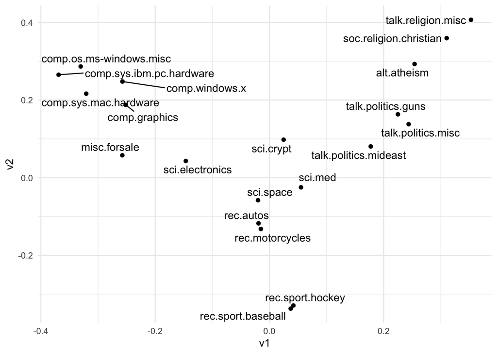

```r
# Question 06
anno %>%
  inner_join(docs, by = "doc_id") %>%
  dsst_pca(doc_var = "label") %>%
  ggplot(aes(v1, v2)) +
    geom_point() +
    geom_text_repel(aes(label = label))
```

Now, produce a corresponding UMAP plot. Is this easier or more difficult to interpret?

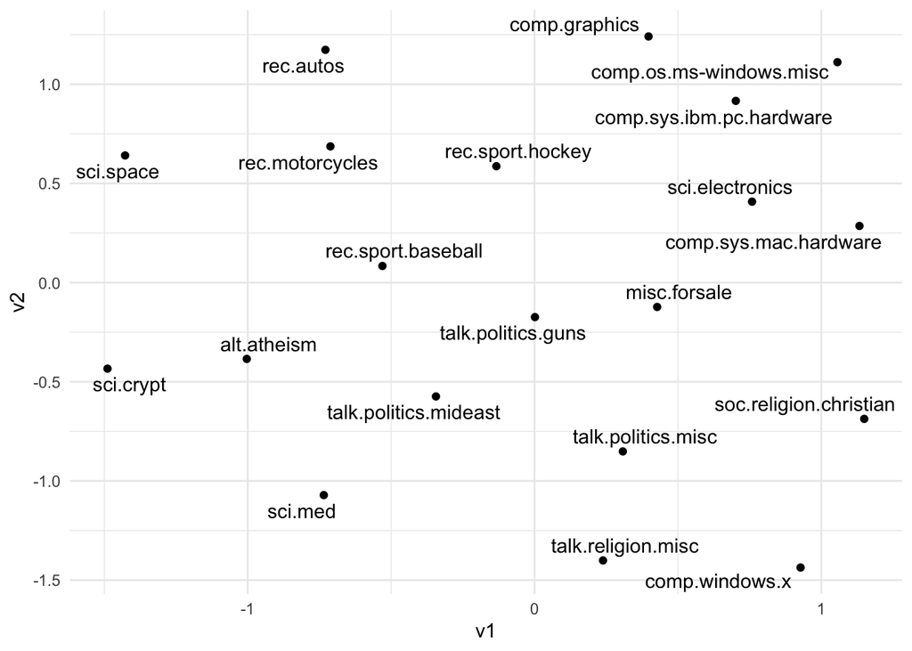

```r
# Question 07
anno %>%
  inner_join(docs, by = "doc_id") %>%
  dsst_umap(doc_var = "label") %>%
  ggplot(aes(v1, v2)) +
    geom_point() +
    geom_text_repel(aes(label = label))
```

Next, produce the principal components for the messages themselves. Save the results as a JSON file and go to the link below to visualize the results. Color the points based on the labels.

- https://statsmaths.github.io/text-embed-explo/build/

```r
# Question 08
dsst_pca(anno) %>% dsst_json_drep(docs, color_var = "label")
```

Repeat the last question for the UMAP parameters. Did you find any interesting clusters of documents?

```r
# Question 09
dsst_umap(anno) %>% dsst_json_drep(docs, color_var = "label")
```

Make sure to not rush through this step; take a couple minutes to pan around in the embedding space.